# Project: Investigate a Dataset - noshowappoinments kagglev2 may 2016

- Introduction
- Data Wrangling
- Exploratory Data Analysis
- Conclusions

## Introduction

A number of characteristics about the patient are included in each row. ● ‘ScheduledDay’ tells us on what day the patient set up their appointment. ● ‘Neighborhood’ indicates the location of the hospital. ● ‘Scholarship’ indicates whether or not the patient is enrolled in Brasilian welfare program Bolsa Família. ● Be careful about the encoding of the last column: it says ‘No’ if the patient showed up to their appointment, and ‘Yes’ if they did not show up.

### Dataset Description

This dataset collects information from 100k medical appointments in Brazil and is focused on the question of whether or not patients show up for their appointment.

### Question(s) for Analysis

Q1- Is there a correlation between missing the appointment and the age of the patient?

Q2- Is there a correlation between missing the appointment and the Gender of the patient?

Q3- Is there a correlation between missing the appointment and the Neighbourhood?

Q4- Is there a correlation between missing the appointment and not receiving an SMS message?

```python
#importing statements for all of the packages to use
import pandas as pd
import numpy as np
import matplotlib.pyplot as plt
import seaborn as sns
#magic word for plotting that my visualizations
%matplotlib inline
```

```python
# Upgrade pandas to use dataframe.explode() function.
!pip install --upgrade pandas==0.25.0
```

## Data Wrangling

> In this section of report we will load in the data. check for cleainess and hen trim and clean the dataset for analysis.

### General Properties

```python
# Loading dataset
df = pd.read_csv('noshowappointments-kagglev2-may-2016.csv')
df.head()
```

|  | PatientId | AppointmentID | Gender | ScheduledDay | AppointmentDay | Age | Neighbourhood | Scholarship | Hipertension | Diabetes | Alcoholism | Handcap | SMS_received | No-show |
| --- | --- | --- | --- | --- | --- | --- | --- | --- | --- | --- | --- | --- | --- | --- |
| 0 | 2.987250e+13 | 5642903 | F | 2016-04-29T18:38:08Z | 2016-04-29T00:00:00Z | 62 | JARDIM DA PENHA | 0 | 1 | 0 | 0 | 0 | 0 | No |
| 1 | 5.589978e+14 | 5642503 | M | 2016-04-29T16:08:27Z | 2016-04-29T00:00:00Z | 56 | JARDIM DA PENHA | 0 | 0 | 0 | 0 | 0 | 0 | No |
| 2 | 4.262962e+12 | 5642549 | F | 2016-04-29T16:19:04Z | 2016-04-29T00:00:00Z | 62 | MATA DA PRAIA | 0 | 0 | 0 | 0 | 0 | 0 | No |
| 3 | 8.679512e+11 | 5642828 | F | 2016-04-29T17:29:31Z | 2016-04-29T00:00:00Z | 8 | PONTAL DE CAMBURI | 0 | 0 | 0 | 0 | 0 | 0 | No |
| 4 | 8.841186e+12 | 5642494 | F | 2016-04-29T16:07:23Z | 2016-04-29T00:00:00Z | 56 | JARDIM DA PENHA | 0 | 1 | 1 | 0 | 0 | 0 | No |

```python
#exploring shape of data
df.shape
```

```
(110527, 14)
```

Data consists of 110527 appoinments and 14 columns

```python
#checking for duplication
df.duplicated().sum()
```

```
0
```

there is no identical duplication of rows

```python
# Check if there is rows with the same only patient id and appointment id
df.duplicated(["PatientId","AppointmentID"]).sum()
```

```
0
```

There is no duplicate values in the dataset

```python
#checking for number of patients Id and noshow
#checking if there were patients Id's duplicated but differ in the noshow status
df.duplicated(["PatientId","No-show"]).sum()
```

```
38710
```

There are 38710 patients whose Ids have same status of showing or not we will remove them in the cleaning data stage

```python
#inspecting for any missing values or any issues to be handled
df.info()
```

```
<class 'pandas.core.frame.DataFrame'>
RangeIndex: 110527 entries, 0 to 110526
Data columns (total 14 columns):
PatientId         110527 non-null float64
AppointmentID     110527 non-null int64
Gender            110527 non-null object
ScheduledDay      110527 non-null object
AppointmentDay    110527 non-null object
Age               110527 non-null int64
Neighbourhood     110527 non-null object
Scholarship       110527 non-null int64
Hipertension      110527 non-null int64
Diabetes          110527 non-null int64
Alcoholism        110527 non-null int64
Handcap           110527 non-null int64
SMS_received      110527 non-null int64
No-show           110527 non-null object
dtypes: float64(1), int64(8), object(5)
memory usage: 11.8+ MB
```

No missing values

```python
#getting more information about our data
df.describe()
```

|  | PatientId | AppointmentID | Age | Scholarship | Hipertension | Diabetes | Alcoholism | Handcap | SMS_received |
| --- | --- | --- | --- | --- | --- | --- | --- | --- | --- |
| count | 1.105270e+05 | 1.105270e+05 | 110527.000000 | 110527.000000 | 110527.000000 | 110527.000000 | 110527.000000 | 110527.000000 | 110527.000000 |
| mean | 1.474963e+14 | 5.675305e+06 | 37.088874 | 0.098266 | 0.197246 | 0.071865 | 0.030400 | 0.022248 | 0.321026 |
| std | 2.560949e+14 | 7.129575e+04 | 23.110205 | 0.297675 | 0.397921 | 0.258265 | 0.171686 | 0.161543 | 0.466873 |
| min | 3.921784e+04 | 5.030230e+06 | -1.000000 | 0.000000 | 0.000000 | 0.000000 | 0.000000 | 0.000000 | 0.000000 |
| 25% | 4.172614e+12 | 5.640286e+06 | 18.000000 | 0.000000 | 0.000000 | 0.000000 | 0.000000 | 0.000000 | 0.000000 |
| 50% | 3.173184e+13 | 5.680573e+06 | 37.000000 | 0.000000 | 0.000000 | 0.000000 | 0.000000 | 0.000000 | 0.000000 |
| 75% | 9.439172e+13 | 5.725524e+06 | 55.000000 | 0.000000 | 0.000000 | 0.000000 | 0.000000 | 0.000000 | 1.000000 |
| max | 9.999816e+14 | 5.790484e+06 | 115.000000 | 1.000000 | 1.000000 | 1.000000 | 1.000000 | 4.000000 | 1.000000 |

Many are not handicapped

```python
#indentifying the row index of -1 values for the age
mask=df.query("Age == -1")
mask
```

|  | PatientId | AppointmentID | Gender | ScheduledDay | AppointmentDay | Age | Neighbourhood | Scholarship | Hipertension | Diabetes | Alcoholism | Handcap | SMS_received | No-show |
| --- | --- | --- | --- | --- | --- | --- | --- | --- | --- | --- | --- | --- | --- | --- |
| 99832 | 4.659432e+14 | 5775010 | F | 2016-06-06T08:58:13Z | 2016-06-06T00:00:00Z | -1 | ROMÃO | 0 | 0 | 0 | 0 | 0 | 0 | No |

### Data Cleaning

```python
#removing the -1 value for 0
df.drop(index=99832,inplace=True)
```

```python
df.describe()
```

|  | PatientId | AppointmentID | Age | Scholarship | Hipertension | Diabetes | Alcoholism | Handcap | SMS_received |
| --- | --- | --- | --- | --- | --- | --- | --- | --- | --- |
| count | 1.105260e+05 | 1.105260e+05 | 110526.000000 | 110526.000000 | 110526.000000 | 110526.000000 | 110526.000000 | 110526.000000 | 110526.000000 |
| mean | 1.474934e+14 | 5.675304e+06 | 37.089219 | 0.098266 | 0.197248 | 0.071865 | 0.030400 | 0.022248 | 0.321029 |
| std | 2.560943e+14 | 7.129544e+04 | 23.110026 | 0.297676 | 0.397923 | 0.258266 | 0.171686 | 0.161543 | 0.466874 |
| min | 3.921784e+04 | 5.030230e+06 | 0.000000 | 0.000000 | 0.000000 | 0.000000 | 0.000000 | 0.000000 | 0.000000 |
| 25% | 4.172536e+12 | 5.640285e+06 | 18.000000 | 0.000000 | 0.000000 | 0.000000 | 0.000000 | 0.000000 | 0.000000 |
| 50% | 3.173184e+13 | 5.680572e+06 | 37.000000 | 0.000000 | 0.000000 | 0.000000 | 0.000000 | 0.000000 | 0.000000 |
| 75% | 9.438963e+13 | 5.725523e+06 | 55.000000 | 0.000000 | 0.000000 | 0.000000 | 0.000000 | 0.000000 | 1.000000 |
| max | 9.999816e+14 | 5.790484e+06 | 115.000000 | 1.000000 | 1.000000 | 1.000000 | 1.000000 | 4.000000 | 1.000000 |

```python
df.rename(columns={"Hipertension":"Hypertension"},inplace=True)
df.rename(columns={"No-show":"No_show"},inplace=True)
df.head()
```

|  | PatientId | AppointmentID | Gender | ScheduledDay | AppointmentDay | Age | Neighbourhood | Scholarship | Hypertension | Diabetes | Alcoholism | Handcap | SMS_received | No_show |
| --- | --- | --- | --- | --- | --- | --- | --- | --- | --- | --- | --- | --- | --- | --- |
| 0 | 2.987250e+13 | 5642903 | F | 2016-04-29T18:38:08Z | 2016-04-29T00:00:00Z | 62 | JARDIM DA PENHA | 0 | 1 | 0 | 0 | 0 | 0 | No |
| 1 | 5.589978e+14 | 5642503 | M | 2016-04-29T16:08:27Z | 2016-04-29T00:00:00Z | 56 | JARDIM DA PENHA | 0 | 0 | 0 | 0 | 0 | 0 | No |
| 2 | 4.262962e+12 | 5642549 | F | 2016-04-29T16:19:04Z | 2016-04-29T00:00:00Z | 62 | MATA DA PRAIA | 0 | 0 | 0 | 0 | 0 | 0 | No |
| 3 | 8.679512e+11 | 5642828 | F | 2016-04-29T17:29:31Z | 2016-04-29T00:00:00Z | 8 | PONTAL DE CAMBURI | 0 | 0 | 0 | 0 | 0 | 0 | No |
| 4 | 8.841186e+12 | 5642494 | F | 2016-04-29T16:07:23Z | 2016-04-29T00:00:00Z | 56 | JARDIM DA PENHA | 0 | 1 | 1 | 0 | 0 | 0 | No |

```python
#removing duplicates Ids with duplicated showing status, leaving the duplicated Ids if they differ in the showing status
#as the same patients may, have several appoinments, attend some and absent from others.
df.drop_duplicates(["PatientId","No_show"],inplace=True)
df.shape
```

```
(71816, 14)
```

```python
#removing unnecessary data
df.drop(["PatientId","AppointmentID","ScheduledDay","AppointmentDay"],axis=1,inplace=True)
df.head()
```

|  | Gender | Age | Neighbourhood | Scholarship | Hypertension | Diabetes | Alcoholism | Handcap | SMS_received | No_show |
| --- | --- | --- | --- | --- | --- | --- | --- | --- | --- | --- |
| 0 | F | 62 | JARDIM DA PENHA | 0 | 1 | 0 | 0 | 0 | 0 | No |
| 1 | M | 56 | JARDIM DA PENHA | 0 | 0 | 0 | 0 | 0 | 0 | No |
| 2 | F | 62 | MATA DA PRAIA | 0 | 0 | 0 | 0 | 0 | 0 | No |
| 3 | F | 8 | PONTAL DE CAMBURI | 0 | 0 | 0 | 0 | 0 | 0 | No |
| 4 | F | 56 | JARDIM DA PENHA | 0 | 1 | 1 | 0 | 0 | 0 | No |

# Data Wrangling Summary

> After gathering the data from the csv file, i explored the first few rows of the dataset and its general properties. then i showed the dimension of my data. i checked if there were any duplicated appointments. i also checked if there were any duplicated IDs and removed them. i looked into datainformation like data types and if there were any missing data to handle. finally i cleared some data by correcting the column names and dropping unnecessary informations.

## General look

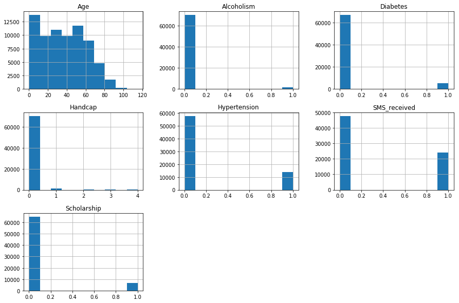

```python
# Use this, and more code cells, to explore your data. Don't forget to add
#   Markdown cells to document your observations and findings.
df.hist(figsize=(15,10));
```

```python
#dividing the patients to 2 groups to show or then expore them
show=df.No_show=="No"
noshow=df.No_show=="Yes"
df[show].count(),df[noshow].count()
```

```
(Gender           54153
 Age              54153
 Neighbourhood    54153
 Scholarship      54153
 Hypertension     54153
 Diabetes         54153
 Alcoholism       54153
 Handcap          54153
 SMS_received     54153
 No_show          54153
 dtype: int64, Gender           17663
 Age              17663
 Neighbourhood    17663
 Scholarship      17663
 Hypertension     17663
 Diabetes         17663
 Alcoholism       17663
 Handcap          17663
 SMS_received     17663
 No_show          17663
 dtype: int64)
```

No of showed patients is (54*54) 3 times greater than the number of no who did not show up (17663)

```python
df[show].mean(),df[noshow].mean()
```

```
(Age             37.229166
 Scholarship      0.091334
 Hypertension     0.202944
 Diabetes         0.072868
 Alcoholism       0.023600
 Handcap          0.020904
 SMS_received     0.297232
 dtype: float64, Age             34.376267
 Scholarship      0.108419
 Hypertension     0.170922
 Diabetes         0.065108
 Alcoholism       0.029440
 Handcap          0.017777
 SMS_received     0.453094
 dtype: float64)
```

mean age for showed patients is 37, while no showed is 34. showed patients received less sms than no show patients. this means that sms campaign has to be revived.

# The ratio between males and females

```
F    65.0
M    35.0
Name: Gender, dtype: float64
```

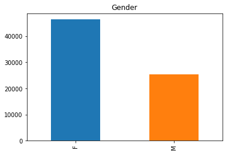

```python
print(round(df.Gender.value_counts()/len(df)*100))
#
df.Gender.value_counts().plot(kind="bar")
plt.title("Gender");
```

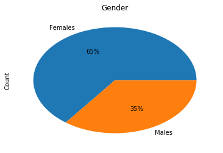

```python
df["Gender"].value_counts().plot(kind="pie",labels=["Females","Males"],   autopct='%1.0f%%')
plt.ylabel("Count")
plt.title("Gender");
```

```python
print("The ratio of females to males : (",(df.Gender == "F").sum() ,":", (df.Gender == "M").sum() ,") -> ", round((df.Gender == "F").sum() / (df.Gender == "M").sum(),2),sep="" )
```

```
The ratio of females to males : (46466:25350) -> 1.83
```

# The proportion of females is greater than that of males

> (the number of females is near twice the number of men)

# Age Exploration

```python
# Basic info about Age
df.Age.describe()
```

```
count    71816.000000
mean        36.527501
std         23.378262
min          0.000000
25%         17.000000
50%         36.000000
75%         55.000000
max        115.000000
Name: Age, dtype: float64
```

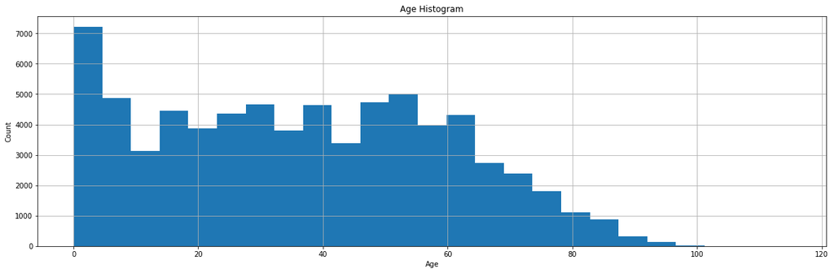

```python
# Histogram plot of Age
df.Age.hist(bins=25,figsize=(20,6))
plt.xlabel("Age")
plt.ylabel("Count")
plt.title("Age Histogram");
```

```python
#df.Age.plot(kind="pie")
```

# Neighbourhood

```python
df.Neighbourhood.value_counts()
```

```
JARDIM CAMBURI                 4800
MARIA ORTIZ                    3845
RESISTÊNCIA                    2780
JARDIM DA PENHA                2696
ITARARÉ                        2470
CENTRO                         2165
TABUAZEIRO                     2121
SANTA MARTHA                   1981
SANTO ANTÔNIO                  1879
BONFIM                         1834
JESUS DE NAZARETH              1755
CARATOÍRA                      1703
JABOUR                         1635
SANTO ANDRÉ                    1594
SÃO PEDRO                      1570
NOVA PALESTINA                 1547
DA PENHA                       1490
GURIGICA                       1387
ANDORINHAS                     1366
ILHA DO PRÍNCIPE               1343
ROMÃO                          1306
BELA VISTA                     1293
SÃO CRISTÓVÃO                  1240
SÃO JOSÉ                       1213
MARUÍPE                        1207
ILHA DE SANTA MARIA            1123
FORTE SÃO JOÃO                 1093
SÃO BENEDITO                    993
JOANA D´ARC                     974
REDENÇÃO                        969
                               ...
ESTRELINHA                      349
SANTA CLARA                     326
SANTOS REIS                     323
SOLON BORGES                    304
PIEDADE                         296
SANTA CECÍLIA                   285
SANTA LUÍZA                     266
DO MOSCOSO                      265
SANTA LÚCIA                     262
BARRO VERMELHO                  257
MÁRIO CYPRESTE                  219
BOA VISTA                       213
ARIOVALDO FAVALESSA             204
DE LOURDES                      197
ANTÔNIO HONÓRIO                 195
COMDUSA                         175
ENSEADA DO SUÁ                  161
FRADINHOS                       150
SANTA HELENA                    121
HORTO                           118
UNIVERSITÁRIO                   106
SEGURANÇA DO LAR                 98
NAZARETH                         96
MORADA DE CAMBURI                77
PONTAL DE CAMBURI                50
ILHA DO BOI                      24
AEROPORTO                         7
ILHA DO FRADE                     6
ILHAS OCEÂNICAS DE TRINDADE       2
PARQUE INDUSTRIAL                 1
Name: Neighbourhood, Length: 81, dtype: int64
```

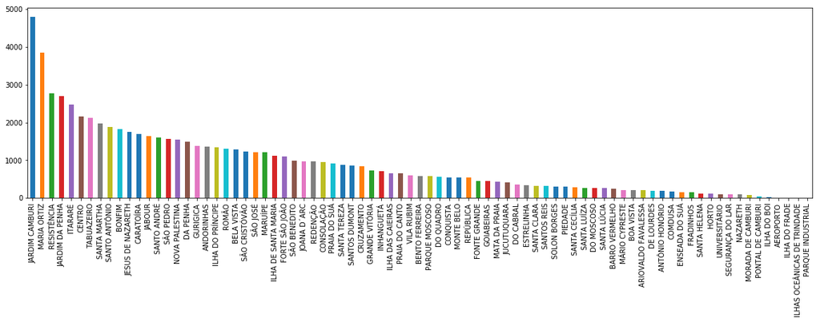

```python
df.Neighbourhood.value_counts().plot(kind="bar",figsize=(20,5));
```

```python
# function to find the value counts percentage and plot barplot figure
def percent_and_barplot(col):
    print(round(df[col].value_counts()/len(df)*100,2))
    df[col].value_counts().plot(kind="bar")
    plt.ylabel("Count")
    plt.title(col);
```

# Scholarship

```
0    90.45
1     9.55
Name: Scholarship, dtype: float64
```

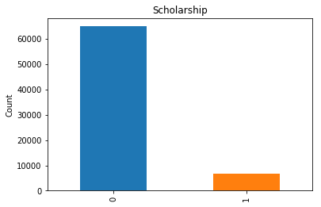

```python
percent_and_barplot("Scholarship")
```

# Hipertension

```
0    80.49
1    19.51
Name: Hypertension, dtype: float64
```

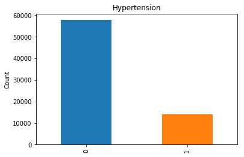

```python
percent_and_barplot("Hypertension")
```

# Diabetes

```
0    92.9
1     7.1
Name: Diabetes, dtype: float64
```

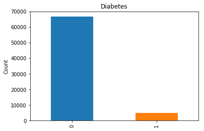

```python
percent_and_barplot("Diabetes");
```

# Alcoholism

```
0    97.5
1     2.5
Name: Alcoholism, dtype: float64
```

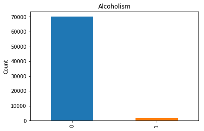

```python
percent_and_barplot("Alcoholism");
```

# Handicap

```
0    98.18
1     1.64
2     0.16
3     0.01
4     0.00
Name: Handcap, dtype: float64
```

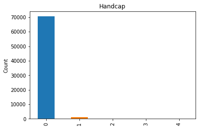

```python
percent_and_barplot("Handcap");
```

# SMS_received

```
0    66.44
1    33.56
Name: SMS_received, dtype: float64
```

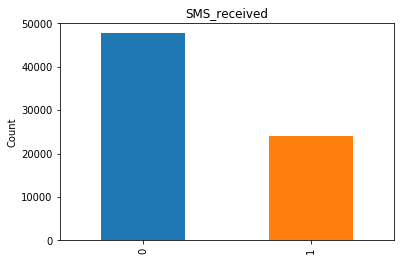

```python
percent_and_barplot("SMS_received");
```

# No_show

```
No     75.41
Yes    24.59
Name: No_show, dtype: float64
```

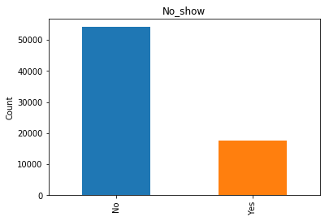

```python
percent_and_barplot("No_show");
```

# General Exploration Results:

The proportion of females is greater than that of males.

The Age range is contain nearly all ages (from 0 to 115) and the majority is in very young age and between 20 and 55.

There is 81 neighbourhood where the appointment takes place.

Most of the patients have No : Scholarship 90% , Hipertension 80%, Diabetes 93% , Alcoholism 97% , Handcap 98% (('according to the data')).

# Exploratory Data Analysis

The main goal of this analysis is to find why patients miss their appointment. and this will be done by finding the relationships between the patients who missed and Attended their appointment and the other charactrestics in the dataset.

Q1- Is there a correlation between missing the appointment and the age of the patient?

Q2- Is there a correlation between missing the appointment and the Gender of the patient?

Q3- Is there a correlation between missing the appointment and the Neighbourhood?

Q4- Is there a correlation between missing the appointment and not receiving an SMS message?

# Question 1: Is there a correlation between missing the appointment and the age of the patient?

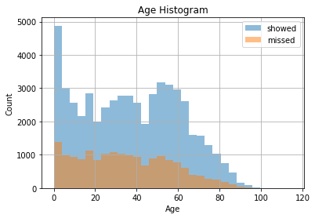

```python
#does age affect the attendance?
df[show].Age.hist(alpha=0.5, bins=30,label="showed")
df[noshow].Age.hist(alpha=0.5, bins=30,label="missed")
plt.legend();
plt.title("Age Histogram")
plt.xlabel("Age")
plt.ylabel("Count");
```

```python
# value counts for no-show grouped by Age
Age_count = df.groupby("Age")["No_show"].value_counts()
Age_count
```

```
Age  No_show
0    No         1828
     Yes         573
1    No         1245
     Yes         369
2    No          967
     Yes         222
3    No          838
     Yes         229
4    No          707
     Yes         234
5    No          783
     Yes         267
6    No          750
     Yes         250
7    No          736
     Yes         227
8    No          715
     Yes         252
9    No          634
     Yes         263
10   No          609
     Yes         227
11   No          605
     Yes         196
12   No          540
     Yes         209
13   No          536
     Yes         218
14   No          507
     Yes         220
                ...
86   Yes          33
87   No          106
     Yes          26
88   No           85
     Yes          11
89   No           86
     Yes          20
90   No           51
```

[output cut: 8 more lines]

```
     Yes           6
95   No           12
     Yes           4
96   No           14
     Yes           1
97   No            7
     Yes           2
98   No            4
     Yes           1
99   No            1
100  No            3
102  No            2
115  No            2
     Yes           1
Name: No_show, Length: 203, dtype: int64
```

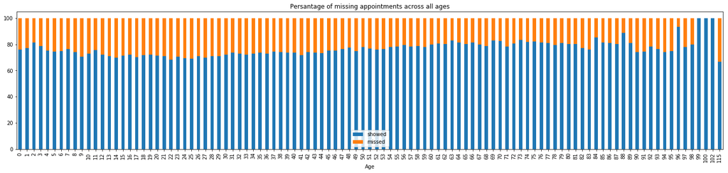

```python
# Stacked bar plot for the patients who missed thier appointment across all ages
round(Age_count / Age_count.groupby(level=0).sum() * 100,2).unstack().plot(kind="bar",stacked=True, figsize=(25,5));
plt.legend(["showed","missed"]);
plt.title("Persantage of missing appointments across all ages");
```

```python
# The mean value of percentage of age for patient that missing thier appointment
print("The mean value of patient missing the appointment for the age:")
round(Age_count / Age_count.groupby(level=0).sum() * 100,2).unstack().Yes.mean()
```

```
The mean value of patient missing the appointment for the age:
```

```
23.651
```

# bining age

Dividing Age into bins with a width of 10, to get a clear look on each age group:

```python
bins=[0,10,20,30,40,50,60,70,80,90,100,120]
df["Age_bin10"] = pd.cut(df.Age, bins=bins)
Age10_count = df.groupby("Age_bin10")["No_show"].value_counts()
```

```python
Age10_count
```

```
Age_bin10   No_show
(0, 10]     No         7984
            Yes        2540
(10, 20]    No         6286
            Yes        2476
(20, 30]    No         6345
            Yes        2681
(30, 40]    No         6912
            Yes        2512
(40, 50]    No         6750
            Yes        2247
(50, 60]    No         7726
            Yes        2190
(60, 70]    No         5774
            Yes        1351
(70, 80]    No         3033
            Yes         716
(80, 90]    No         1352
            Yes         331
(90, 100]   No          159
            Yes          45
(100, 120]  No            4
            Yes           1
Name: No_show, dtype: int64
```

```
Text(0.5,1,'Percentage of Missing appointment across ages')
```

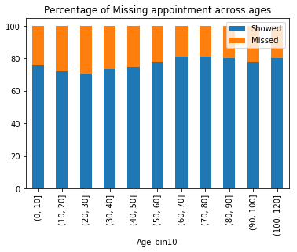

```python
(Age10_count/Age10_count.groupby(level=0).sum()*100).unstack().plot(kind="bar",stacked=True)
plt.legend(["Showed","Missed"]);
plt.title("Percentage of Missing appointment across ages")
```

```python
(Age10_count/Age10_count.groupby(level=0).sum()*100)
```

```
Age_bin10   No_show
(0, 10]     No         75.864690
            Yes        24.135310
(10, 20]    No         71.741612
            Yes        28.258388
(20, 30]    No         70.296920
            Yes        29.703080
(30, 40]    No         73.344652
            Yes        26.655348
(40, 50]    No         75.025008
            Yes        24.974992
(50, 60]    No         77.914482
            Yes        22.085518
(60, 70]    No         81.038596
            Yes        18.961404
(70, 80]    No         80.901574
            Yes        19.098426
(80, 90]    No         80.332739
            Yes        19.667261
(90, 100]   No         77.941176
            Yes        22.058824
(100, 120]  No         80.000000
            Yes        20.000000
Name: No_show, dtype: float64
```

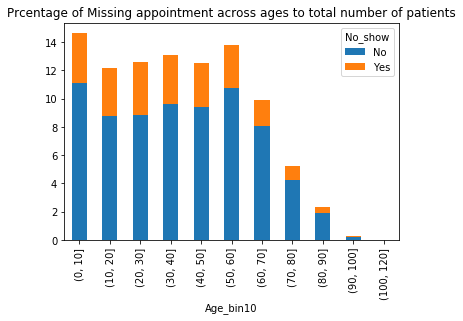

```python
# ratio to all patients
(Age10_count/len(df)*100).unstack().plot(kind="bar",stacked=True);
plt.title("Prcentage of Missing appointment across ages to total number of patients");
```

```python
#(Age10_count/Age10_count.groupby(level=0).sum()*100).unstack().mean()
```

```python
#(Age10_count/Age10_count.groupby(level=0).sum()*100).unstack().Yes.hist(bins=30);
```

# Results:

There is no strong corolation between age alone and missing the appointment :

1. patients from 12 to mid 30s are more likely to miss their appointments
2. kids and patients in their 60s, 70s and 80s are more likely to show to their appointments : The reason for that could be because there is someone who is taking them to their appointments.

### Research Question 2 Is there a correlation between missing the appointment and the Gender of the patient?

```python
# Gender count
Gender_count = df.groupby("Gender")["No_show"].value_counts()
print(Gender_count)
```

```
Gender  No_show
F       No         34960
        Yes        11506
M       No         19193
        Yes         6157
Name: No_show, dtype: int64
```

```
The percentage of females who missed their appointment:  24.76
The percentage of males who missed their appointment  :  24.29
```

```
Text(0.5,1,'The percentage of male and females')
```

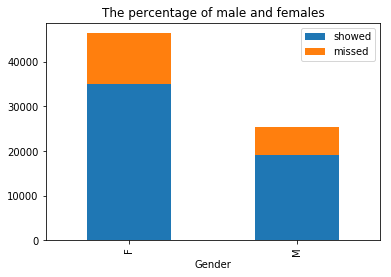

```python
print("The percentage of females who missed their appointment: ",round(Gender_count[1]/(Gender_count[0]+Gender_count[1])*100,2))
print("The percentage of males who missed their appointment  : ",round(Gender_count[3]/(Gender_count[3]+Gender_count[2])*100,2))
df.groupby("Gender")["No_show"].value_counts().unstack().plot(kind="bar",stacked=True)
plt.legend(["showed","missed"]);
plt.title("The percentage of male and females")
```

# Results:

we could say that there is no corolation between gender alone and missing the appointment.

The percentage of male and female patients missing their appointments is the same and same as the general average.

# Question 3- Is there a correlation between missing the appointment and the Neighbourhood?

```python
Neighbourhood_count = df.groupby("Neighbourhood")["No_show"].value_counts()
Neighbourhood_count
```

```
Neighbourhood        No_show
AEROPORTO            No            6
                     Yes           1
ANDORINHAS           No          997
                     Yes         369
ANTÔNIO HONÓRIO      No          155
                     Yes          40
ARIOVALDO FAVALESSA  No          152
                     Yes          52
BARRO VERMELHO       No          189
                     Yes          68
BELA VISTA           No          975
                     Yes         318
BENTO FERREIRA       No          426
                     Yes         152
BOA VISTA            No          163
                     Yes          50
BONFIM               No         1383
                     Yes         451
CARATOÍRA            No         1224
                     Yes         479
CENTRO               No         1610
                     Yes         555
COMDUSA              No          134
                     Yes          41
CONQUISTA            No          433
                     Yes         120
CONSOLAÇÃO           No          754
                     Yes         206
CRUZAMENTO           No          611
                     Yes         238
                                ...
SANTA MARTHA         No         1577
                     Yes         404
SANTA TEREZA         No          676
                     Yes         203
SANTO ANDRÉ          No         1246
                     Yes         348
SANTO ANTÔNIO        No         1488
                     Yes         391
```

[output cut: 8 more lines]

```
SÃO BENEDITO         No          767
                     Yes         226
SÃO CRISTÓVÃO        No          943
                     Yes         297
SÃO JOSÉ             No          920
                     Yes         293
SÃO PEDRO            No         1163
                     Yes         407
TABUAZEIRO           No         1656
                     Yes         465
UNIVERSITÁRIO        No           82
                     Yes          24
VILA RUBIM           No          475
                     Yes         117
Name: No_show, Length: 160, dtype: int64
```

```python
round(Neighbourhood_count / Neighbourhood_count.groupby(level=0).sum() * 100,2).unstack()
```

| No_show Neighbourhood | No | Yes |
| --- | --- | --- |
| AEROPORTO | 85.71 | 14.29 |
| ANDORINHAS | 72.99 | 27.01 |
| ANTÔNIO HONÓRIO | 79.49 | 20.51 |
| ARIOVALDO FAVALESSA | 74.51 | 25.49 |
| BARRO VERMELHO | 73.54 | 26.46 |
| BELA VISTA | 75.41 | 24.59 |
| BENTO FERREIRA | 73.70 | 26.30 |
| BOA VISTA | 76.53 | 23.47 |
| BONFIM | 75.41 | 24.59 |
| CARATOÍRA | 71.87 | 28.13 |
| CENTRO | 74.36 | 25.64 |
| COMDUSA | 76.57 | 23.43 |
| CONQUISTA | 78.30 | 21.70 |
| CONSOLAÇÃO | 78.54 | 21.46 |
| CRUZAMENTO | 71.97 | 28.03 |
| DA PENHA | 76.78 | 23.22 |
| DE LOURDES | 78.68 | 21.32 |
| DO CABRAL | 80.34 | 19.66 |
| DO MOSCOSO | 70.57 | 29.43 |
| DO QUADRO | 81.62 | 18.38 |
| ENSEADA DO SUÁ | 70.81 | 29.19 |
| ESTRELINHA | 72.78 | 27.22 |
| FONTE GRANDE | 74.89 | 25.11 |
| FORTE SÃO JOÃO | 76.67 | 23.33 |
| FRADINHOS | 75.33 | 24.67 |
| GOIABEIRAS | 78.46 | 21.54 |
| GRANDE VITÓRIA | 76.49 | 23.51 |
| GURIGICA | 72.96 | 27.04 |
| HORTO | 66.95 | 33.05 |
| ILHA DAS CAIEIRAS | 73.07 | 26.93 |
| ... | ... | ... |
| PARQUE INDUSTRIAL | 100.00 | NaN |
| PARQUE MOSCOSO | 72.70 | 27.30 |
| PIEDADE | 76.35 | 23.65 |
| PONTAL DE CAMBURI | 76.00 | 24.00 |
| PRAIA DO CANTO | 76.41 | 23.59 |
| PRAIA DO SUÁ | 71.90 | 28.10 |
| REDENÇÃO | 77.30 | 22.70 |
| REPÚBLICA | 79.41 | 20.59 |
| RESISTÊNCIA | 75.47 | 24.53 |
| ROMÃO | 72.59 | 27.41 |
| SANTA CECÍLIA | 66.32 | 33.68 |
| SANTA CLARA | 69.33 | 30.67 |
| SANTA HELENA | 70.25 | 29.75 |
| SANTA LUÍZA | 78.95 | 21.05 |
| SANTA LÚCIA | 75.19 | 24.81 |
| SANTA MARTHA | 79.61 | 20.39 |
| SANTA TEREZA | 76.91 | 23.09 |
| SANTO ANDRÉ | 78.17 | 21.83 |
| SANTO ANTÔNIO | 79.19 | 20.81 |
| SANTOS DUMONT | 66.55 | 33.45 |
| SANTOS REIS | 74.61 | 25.39 |
| SEGURANÇA DO LAR | 79.59 | 20.41 |
| SOLON BORGES | 79.61 | 20.39 |
| SÃO BENEDITO | 77.24 | 22.76 |
| SÃO CRISTÓVÃO | 76.05 | 23.95 |
| SÃO JOSÉ | 75.85 | 24.15 |
| SÃO PEDRO | 74.08 | 25.92 |
| TABUAZEIRO | 78.08 | 21.92 |
| UNIVERSITÁRIO | 77.36 | 22.64 |
| VILA RUBIM | 80.24 | 19.76 |

81 rows × 2 columns

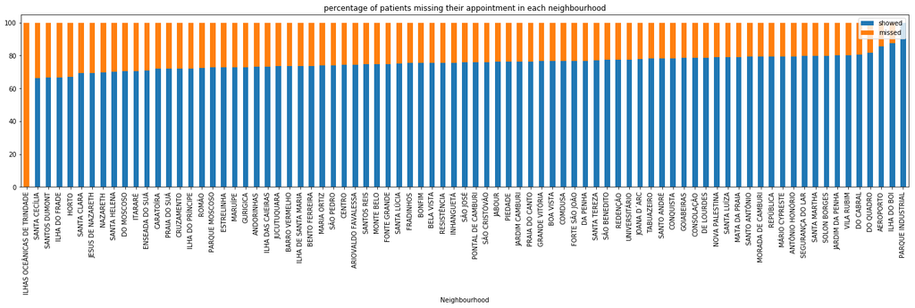

```python
# percentage of patients missing their appointment in each neighbourhood
round(Neighbourhood_count / Neighbourhood_count.groupby(level=0).sum() * 100,2).unstack().sort_values(by="Yes",ascending=False).plot(kind="bar",stacked=True, figsize=(25,5));
plt.legend(["showed","missed"]);
plt.title("percentage of patients missing their appointment in each neighbourhood");
```

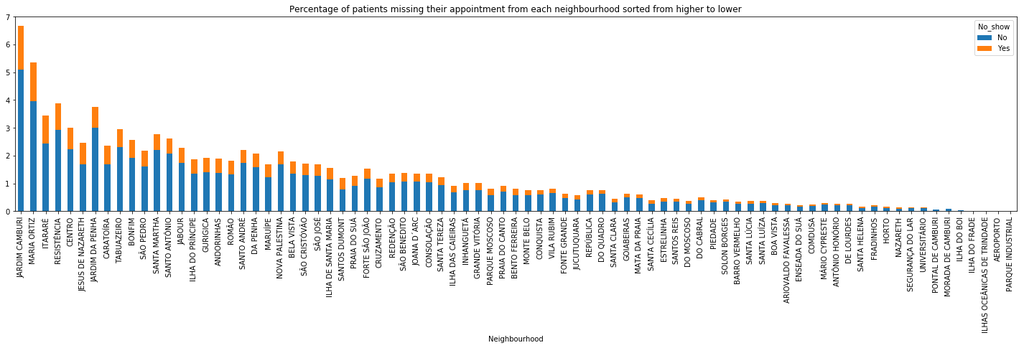

```python
# Percentage of patients missing their appointment from each neighbourhood sorted from higher to lower
round(Neighbourhood_count / len(df) * 100,2).unstack().sort_values(by="Yes",ascending=False).plot(kind="bar",stacked=True, figsize=(25,5));
plt.title("Percentage of patients missing their appointment from each neighbourhood sorted from higher to lower");
```

```python
print("The mean value for the percentage of patients missing appointments in all neighbourhood:",
      round((Neighbourhood_count / Neighbourhood_count.groupby(level=0).sum() * 100).unstack().Yes.mean(),2))
print("The standard deviation value:",round((Neighbourhood_count / Neighbourhood_count.groupby(level=0).sum() * 100).unstack().Yes.std(),2))
```

```
The mean value for the percentage of patients missing appointments in all neighbourhood: 25.45
The standard deviation value: 9.32
```

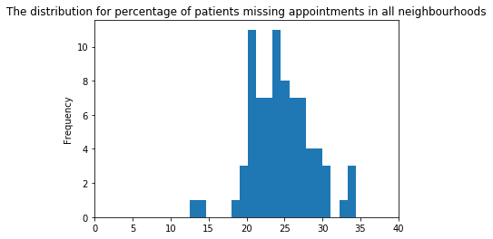

```python
# in this distribution, we removed an outlier value
round(Neighbourhood_count / Neighbourhood_count.groupby(level=0).sum() * 100,2).unstack().Yes.plot(kind="hist",bins=80,xlim=(0,40))
plt.title("The distribution for percentage of patients missing appointments in all neighbourhoods");
```

# Results:

In general, the more patient coming from the neighborhood the more patient will miss their appointments

The neighborhoods with most patients showing to their appointments have low patients numbers. So, we couldn't conclude that these neighborhoods have a higher chance that patients won't miss their appointments.

# Question 4- Is there a correlation between missing the appointment and not receiving an SMS message?

> As we have shown before the majority of patients didn't recived SMS.

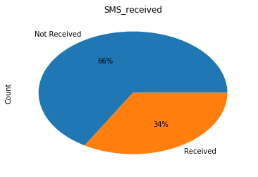

```python
df["SMS_received"].value_counts().plot(kind="pie",labels=["Not Received","Received"],   autopct='%1.0f%%')
plt.ylabel("Count")
plt.title("SMS_received");
```

```python
#checking if patients who received sms showed up for appointment
SMS_count = df.groupby("SMS_received")["No_show"].value_counts()
SMS_count
```

```
SMS_received  No_show
0             No         38057
              Yes         9660
1             No         16096
              Yes         8003
Name: No_show, dtype: int64
```

```python
SMS_YN = (SMS_count / SMS_count.groupby(level=0).sum() * 100).unstack()
SMS_YN.index = ["NOt Received", "Received"]
SMS_YN
```

| No_show | No | Yes |
| --- | --- | --- |
| NOt Received | 79.755643 | 20.244357 |
| Received | 66.791153 | 33.208847 |

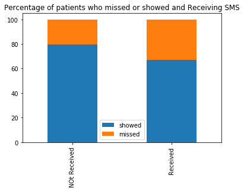

```python
SMS_YN.plot(kind="bar",stacked=True)
plt.legend(["showed","missed"])
plt.title("Percentage of patients who missed or showed and Receiving SMS");
```

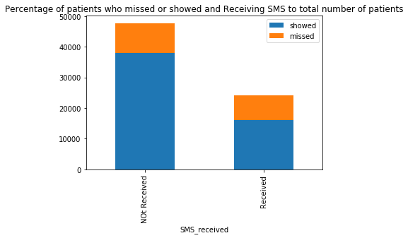

```python
SMS_count.unstack().sort_values(by="Yes",ascending=False).plot(kind="bar",stacked=True).set_xticklabels(["NOt Received", "Received"]);
plt.legend(["showed","missed"])
plt.title("Percentage of patients who missed or showed and Receiving SMS to total number of patients");
```

```python
# Exploring it the other way, percentage of patients who (recived SMS of not) to (missing or showing)
SMS_Miss = (df.groupby("No_show")["SMS_received"].value_counts()/(df.groupby("No_show")["SMS_received"].value_counts().groupby(level=0).sum()/100)).unstack()
SMS_Miss.columns = ["Not Received", "Received"]
SMS_Miss
```

| No_show | Not Received | Received |
| --- | --- | --- |
| No | 70.276808 | 29.723192 |
| Yes | 54.690596 | 45.309404 |

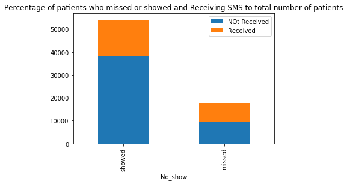

```python
# the percentage of patients who (recived SMS of not) to (missing or showing)
df.groupby("No_show")["SMS_received"].value_counts().unstack().plot(kind="bar",stacked=True).set_xticklabels(["showed","missed"])
plt.legend(["NOt Received", "Received"]);
plt.title("Percentage of patients who missed or showed and Receiving SMS to total number of patients");
```

# Results:

Most patients didn't received an SMS.

According to the data, receiving an SMS, didn't make patients more likely to show to their appointments.

# General correlation table between columns

```python
# Convert "No-show" column to binary values by creatind a new column
df["missed"] = np.where(df["No_show"] == "Yes",1,0)
```

```python
df.corr()
```

|  | Age | Scholarship | Hypertension | Diabetes | Alcoholism | Handcap | SMS_received | missed |
| --- | --- | --- | --- | --- | --- | --- | --- | --- |
| Age | 1.000000 | -0.092138 | 0.515340 | 0.295225 | 0.085677 | 0.081278 | 0.017683 | -0.052553 |
| Scholarship | -0.092138 | 1.000000 | -0.025147 | -0.023403 | 0.034330 | -0.007058 | 0.002476 | 0.025030 |
| Hypertension | 0.515340 | -0.025147 | 1.000000 | 0.428781 | 0.080582 | 0.082555 | -0.008033 | -0.034801 |
| Diabetes | 0.295225 | -0.023403 | 0.428781 | 1.000000 | 0.025137 | 0.055299 | -0.017578 | -0.013015 |
| Alcoholism | 0.085677 | 0.034330 | 0.080582 | 0.025137 | 1.000000 | 0.009638 | -0.010636 | 0.016098 |
| Handcap | 0.081278 | -0.007058 | 0.082555 | 0.055299 | 0.009638 | 1.000000 | -0.019597 | -0.008668 |
| SMS_received | 0.017683 | 0.002476 | -0.008033 | -0.017578 | -0.010636 | -0.019597 | 1.000000 | 0.142150 |
| missed | -0.052553 | 0.025030 | -0.034801 | -0.013015 | 0.016098 | -0.008668 | 0.142150 | 1.000000 |

## Conclusions

We investigated the correlation between some of the characteristics of the patients and whether they missed or showed to their appointment. And these are the results of these analyses:

patients from 12 to mid-30s are more likely to miss their appointments

kids and patients in their 60s, 70s, and 80s are more likely to show to their appointments

There is no correlation between gender alone and missing the appointment.

The neighborhoods with most patients showing to their appointments have low patients numbers. So, we couldn't conclude that these neighborhoods have a higher chance that patients won't miss their appointments.

Receiving an SMS did not increase the chance that the patient would show to their appointment.

## limitations

The period when the data collected was just nearly two months, and this short period doesn't make the data reliable to make a strong correlation

There was no explanation of how the data was collected, and if it was collected in a way that makes these analyses more reliable.

The Handcap and SMS_received columns weren't explained clearly on the dataset page.

The dataset didn't explain why the patient come to the doctor, which may give an additional explanation about why they miss their appointments.

```python
from subprocess import call
call(['python', '-m', 'nbconvert', 'Investigate_a_Dataset.ipynb'])
```

```
0
```